# nmer_OriginalHomeworkCode_03

[figure not shown]

## 5 Challenges

```r
file <- curl('https://raw.githubusercontent.com/fuzzyatelin/fuzzyatelin.github.io/master/AN588_Fall23/zombies.csv')
d <- read.csv(file, header= TRUE, sep = ",", stringsAsFactors = FALSE)
head(d)
```

```
##   id first_name last_name gender   height   weight zombies_killed
## 1  1      Sarah    Little Female 62.88951 132.0872              2
## 2  2       Mark    Duncan   Male 67.80277 146.3753              5
## 3  3    Brandon     Perez   Male 72.12908 152.9370              1
## 4  4      Roger   Coleman   Male 66.78484 129.7418              5
## 5  5      Tammy    Powell Female 64.71832 132.4265              4
## 6  6    Anthony     Green   Male 71.24326 152.5246              1
##   years_of_education                           major      age
## 1                  1                medicine/nursing 17.64275
## 2                  3 criminal justice administration 22.58951
## 3                  1                       education 21.91276
## 4                  6                  energy studies 18.19058
## 5                  3                       logistics 21.10399
## 6                  4                  energy studies 21.48355
```

```r
str(d)
```

```
## 'data.frame':    1000 obs. of  10 variables:
##  $ id                : int  1 2 3 4 5 6 7 8 9 10 ...
##  $ first_name        : chr  "Sarah" "Mark" "Brandon" "Roger" ...
##  $ last_name         : chr  "Little" "Duncan" "Perez" "Coleman" ...
##  $ gender            : chr  "Female" "Male" "Male" "Male" ...
##  $ height            : num  62.9 67.8 72.1 66.8 64.7 ...
##  $ weight            : num  132 146 153 130 132 ...
##  $ zombies_killed    : int  2 5 1 5 4 1 0 4 9 2 ...
##  $ years_of_education: int  1 3 1 6 3 4 4 0 3 3 ...
##  $ major             : chr  "medicine/nursing" "criminal justice administration" "education" "energy studies" ...
##  $ age               : num  17.6 22.6 21.9 18.2 21.1 ...
```

## Question 1

Calculate the population mean and standard deviation for each quantitative random variable (height, weight, age, number of zombies killed, and years of education). NOTE: You will not want to use the built in var() and sd() commands as these are for samples.

```r
h <- d$height
mh <- mean(h)
mh
```

```
## [1] 67.6301
```

```r
w <- d$weight
mw <- mean(w)
mw
```

```
## [1] 143.9075
```

```r
a <- d$age
ma <- mean(a)
ma
```

```
## [1] 20.04696
```

```r
zk <- d$zombies_killed
mzk <- mean(zk)
mzk
```

```
## [1] 2.992
```

```r
ye <- d$years_of_education
mye <- mean(ye)
mye
```

```
## [1] 2.996
```

For population standard deviation, first will define a function for population variance, not sample variance. This is the sum of squares/n.

```r
pop_v <- function(x) {
    sum((x - mean(x))^2)/length(x)
}
pop_v(h)
```

```
## [1] 18.55861
```

```r
pop_v(w)
```

```
## [1] 338.2604
```

```r
pop_v(a)
```

```
## [1] 8.782822
```

```r
pop_v(zk)
```

```
## [1] 3.053936
```

```r
pop_v(ye)
```

```
## [1] 2.807984
```

To get the population SD, I just need to define a function taking the square root of the population variance

```r
pop_sd <- function(x) {
    sqrt(pop_v(x))
}
pop_sd(h)
```

```
## [1] 4.30797
```

```r
pop_sd(w)
```

```
## [1] 18.39186
```

```r
pop_sd(a)
```

```
## [1] 2.963583
```

```r
pop_sd(zk)
```

```
## [1] 1.747551
```

```r
pop_sd(ye)
```

```
## [1] 1.675704
```

## Question 2

Use {ggplot} to make boxplots of each of these variables by gender.

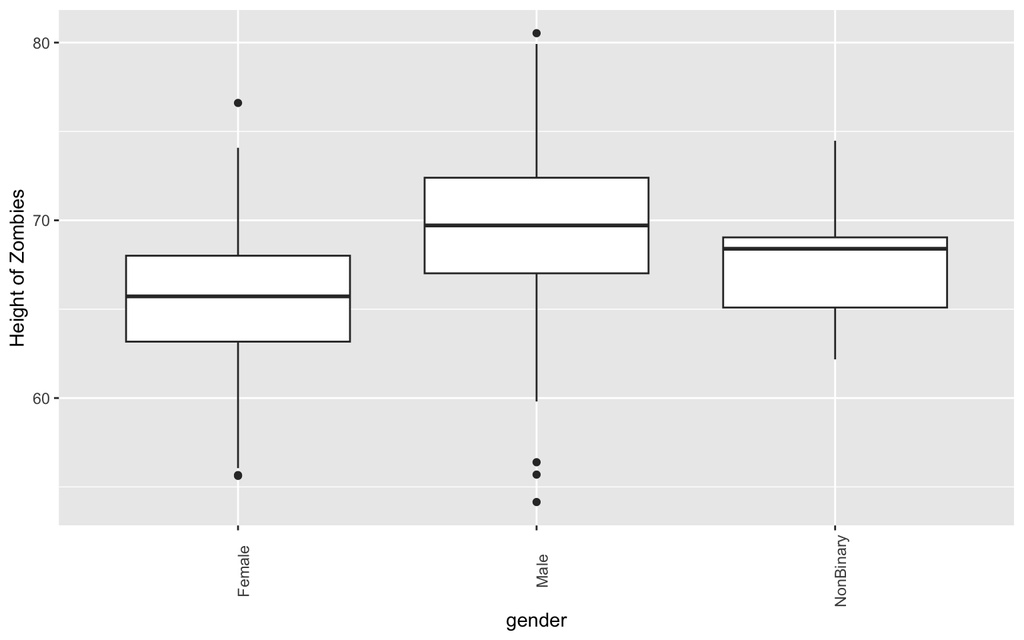

```r
ph <- ggplot(data = d, aes(x = gender, y = h))
ph <- ph + geom_boxplot()
ph <- ph + theme(axis.text.x = element_text(angle = 90))
ph <- ph + ylab("Height of Zombies")
ph
```

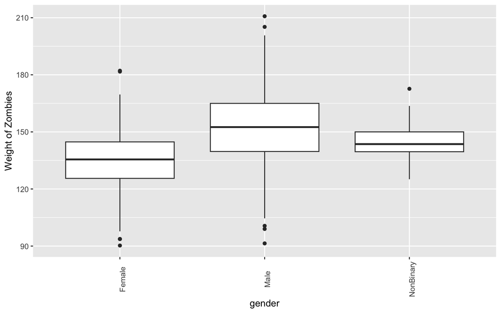

```r
pw <- ggplot(data = d, aes(x = gender, y = w))
pw <- pw + geom_boxplot()
pw <- pw + theme(axis.text.x = element_text(angle = 90))
pw <- pw + ylab("Weight of Zombies")
pw
```

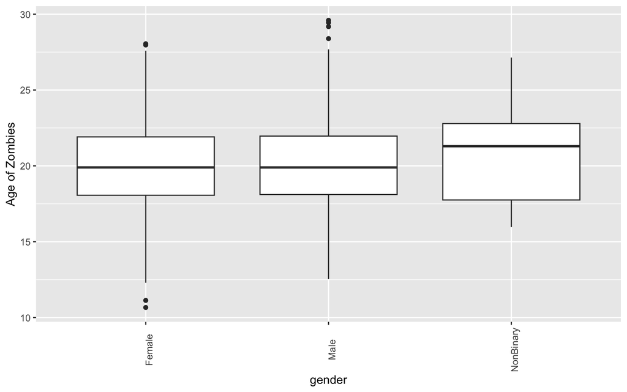

```r
pa <- ggplot(data = d, aes(x = gender, y = a))
pa <- pa + geom_boxplot()
pa <- pa + theme(axis.text.x = element_text(angle = 90))
pa <- pa + ylab("Age of Zombies")
pa
```

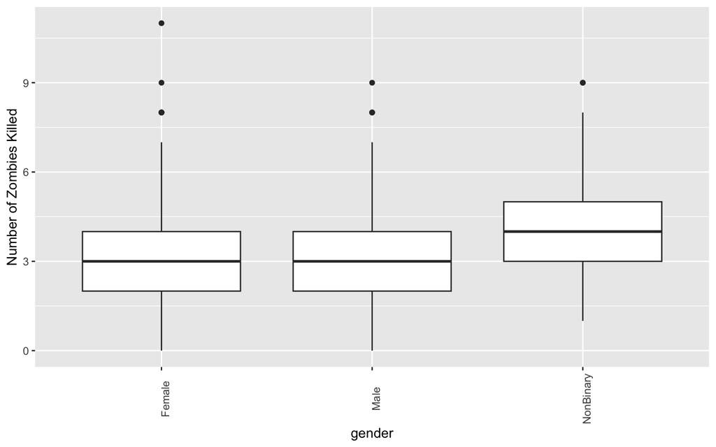

```r
pzk <- ggplot(data = d, aes(x = gender, y = zk))
pzk <- pzk + geom_boxplot()
pzk <- pzk + theme(axis.text.x = element_text(angle = 90))
pzk <- pzk + ylab("Number of Zombies Killed")
pzk
```

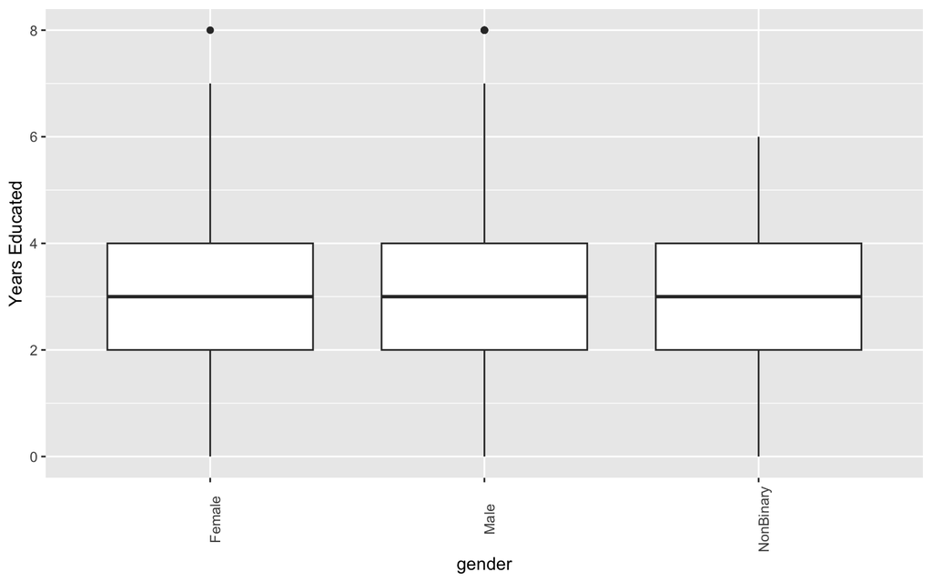

```r
pye <- ggplot(data = d, aes(x = gender, y = ye))
pye <- pye + geom_boxplot()
pye <- pye + theme(axis.text.x = element_text(angle = 90))
pye <- pye + ylab("Years Educated")
pye
```

## Question 3

Use {ggplot} to make scatterplots of height and weight in relation to age. Do these variables seem to be related? In what way?

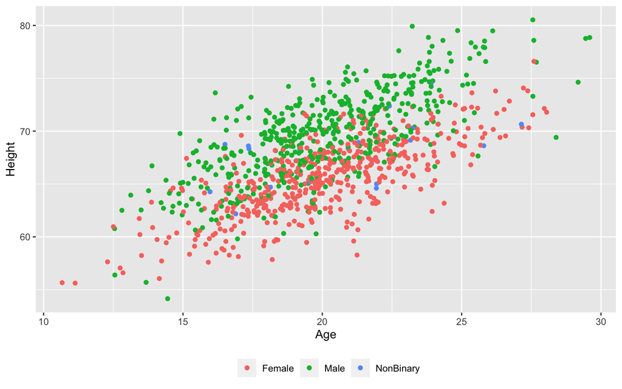

```r
ph1 <- ggplot(data = d, aes(x = a, y = h, color = factor(gender)))
ph1 <- ph1 + xlab("Age") + ylab("Height")
ph1 <- ph1 + geom_point()
ph1 <- ph1 + theme(legend.position = "bottom", legend.title = element_blank())
ph1
```

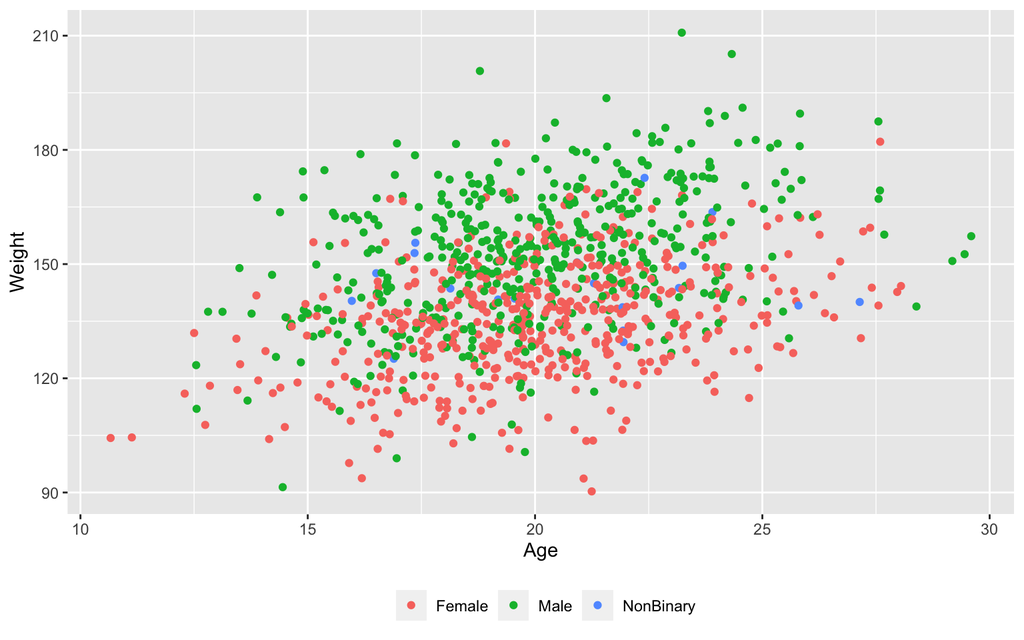

```r
pw1 <- ggplot(data = d, aes(x = a, y = w, color = factor(gender)))
pw1 <- pw1 + xlab("Age") + ylab("Weight")
pw1 <- pw1 + geom_point()
pw1 <- pw1 + theme(legend.position = "bottom", legend.title = element_blank())
pw1
```

## Question 4

Using histograms and Q-Q plots, check whether the quantitative variables seem to be drawn from a normal distribution. Which seem to be and which do not (hint: not all are drawn from the normal distribution)? For those that are not normal, can you determine from which common distribution they are drawn?

```r
par(mfrow = c(1,2))
min(h)
```

```
## [1] 54.14948
```

```r
max(h)
```

```
## [1] 80.5298
```

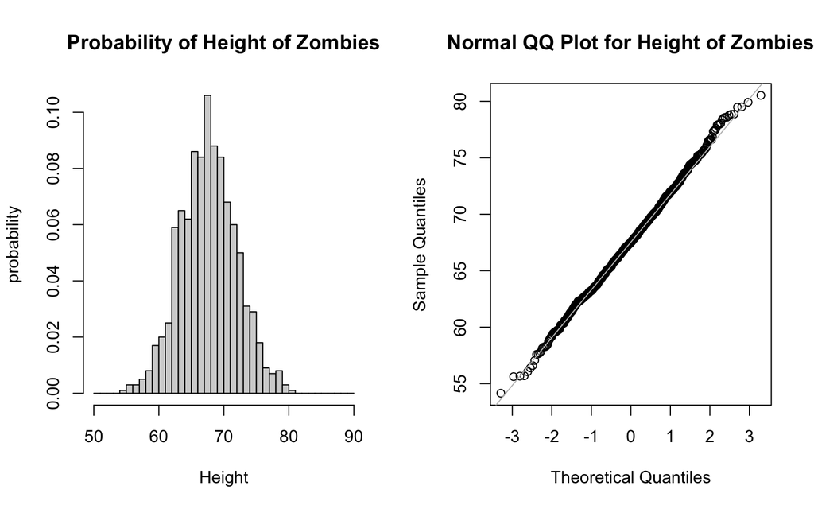

```r
hist(h, breaks = seq(50,90,1), probability= TRUE, main = "Probability of Height of Zombies", xlab = "Height", ylab = "probability")
qqnorm(h, main = "Normal QQ Plot for Height of Zombies")
qqline(h, col = "gray")
```

```r
par(mfrow = c(1,2))
min(w)
```

```
## [1] 90.29148
```

```r
max(w)
```

```
## [1] 210.7895
```

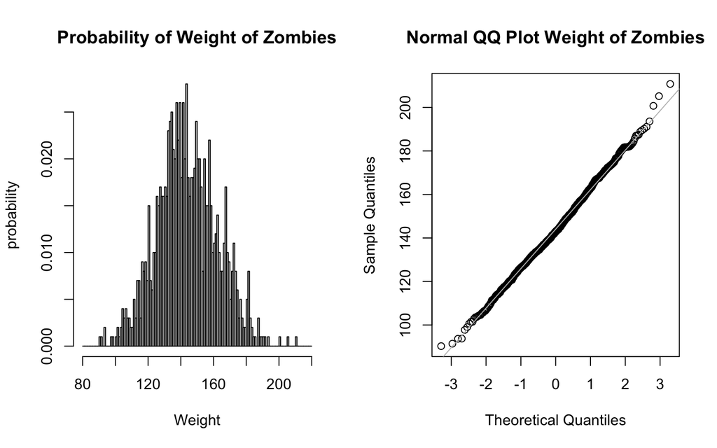

```r
hist(w, breaks = seq(80,220,1), probability= TRUE, main = "Probability of Weight of Zombies", xlab = "Weight", ylab = "probability")
qqnorm(w, main = "Normal QQ Plot Weight of Zombies")
qqline(w, col = "gray")
```

```r
par(mfrow = c(1,2))
min(a)
```

```
## [1] 10.66381
```

```r
max(a)
```

```
## [1] 29.59488
```

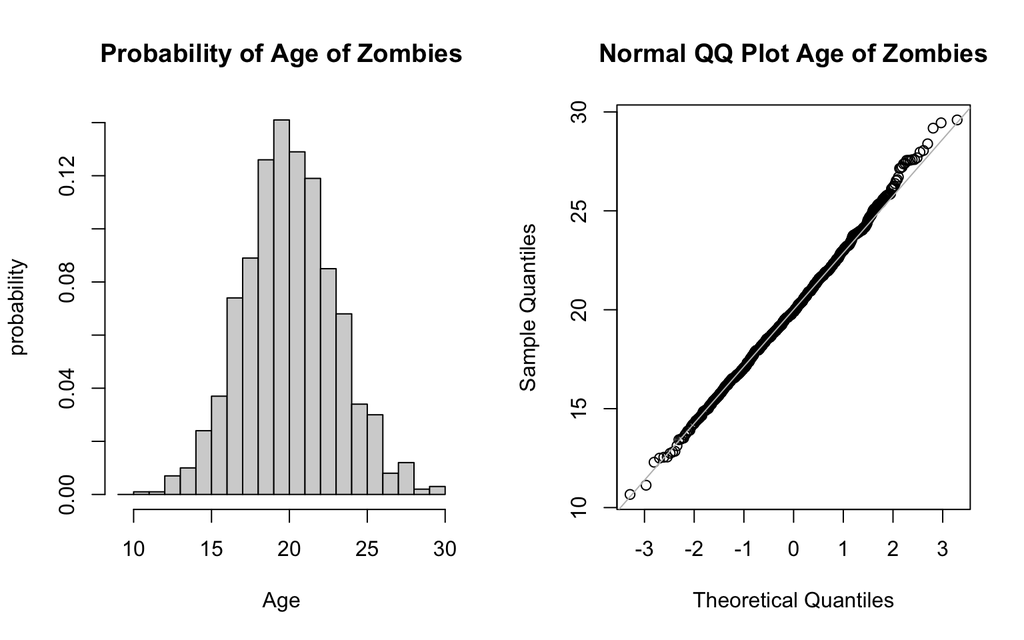

[output not shown]

[output not shown]

```r
hist(a, breaks = seq(9,30,1), probability= TRUE, main = "Probability of Age of Zombies", xlab = "Age", ylab = "probability")
qqnorm(a, main = "Normal QQ Plot Age of Zombies")
qqline(a, col = "gray")
```

```r
max(zk)
```

```
## [1] 11
```

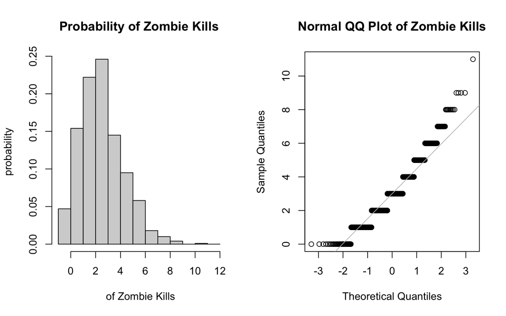

```r
hist(zk, breaks = seq(-1,12,1), probability= TRUE, main = "Probability of Zombie Kills", xlab = " of Zombie Kills", ylab = "probability")
qqnorm(zk, main = "Normal QQ Plot of Zombie Kills")
qqline(zk, col = "gray")
```

This is a poisson distribution which makes sense because it is a similar scenario to the titi calls. How many kills are observed?

```r
par(mfrow = c(1,2))
min(ye)
```

```
## [1] 0
```

```r
max(ye)
```

```
## [1] 8
```

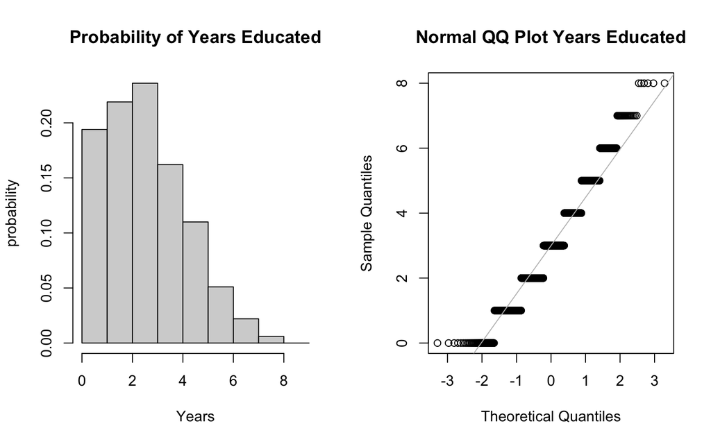

```r
hist(ye, breaks = seq(0,9,1), probability= TRUE, main = "Probability of Years Educated", xlab = "Years", ylab = "probability")
qqnorm(ye, main = "Normal QQ Plot Years Educated")
qqline(ye, col = "gray")
```

This is also a poisson distribution, for similar reasons as above.

## Question 5

Now use the sample() function to sample ONE subset of 30 zombie survivors (without replacement) from this population and calculate the mean and sample standard deviation for each variable. Also estimate the standard error for each variable, and construct the 95% confidence interval for each mean. Note that for the variables that are not drawn from the normal distribution, you may need to base your estimate of the CIs on slightly different code than for the normal…

## Question 6

Now draw 99 more random samples of 30 zombie apocalypse survivors, and calculate the mean for each variable for each of these samples. Together with the first sample you drew, you now have a set of 100 means for each variable (each based on 30 observations), which constitutes a sampling distribution for each variable. What are the means and standard deviations of this distribution of means for each variable? How do the standard deviations of means compare to the standard errors estimated in [5]? What do these sampling distributions look like (a graph might help here)? Are they normally distributed? What about for those variables that you concluded were not originally drawn from a normal distribution?